# Progress Memo 1

Final Project  
Data Science 2 with R (STAT 301-2)

Author

Sana Nanlawala

Published

February 23, 2024

**Github Repo Link**

https://github.com/stat301-2-2024-winter/final-project-2-SanaNanlawala2026.git

## Data source

This dataframe was sourced from Kaggle at: https://www.kaggle.com/datasets/dbdmobile/myanimelist-dataset/

## Why this data

I chose this data set because as someone who interested in anime myself, I would like to see a predictive model built around the ratings that were given to the animes. I think there are a lot of examples of similar models surrounding movies/shows in the West, like with the Netflix Prize dataset for modelling user ratings predictions. It would be interesting to see how it would hold up for anime, which has an entirely demographic of viewers/audience, especially in age.

## Objective/Research Question

What I will be looking specifically is to create regression models to help predict the anime ‘score’ that is the outcome variable of my choosing in this dataset. Some predictors will include duration, rating, popularity, favorites, watching, on-hold.

## Data quality & complexity check

Below, I am reading in the dataset named anime. There are currently 25 variables, of which 9 are numeric and the other character/categorical. I will not be using all 25 variables, as many of them are unrelated or irrelevant such as the id, and the synopsis of the show. However, below I will show in the general reading in of the dataset (excluding the synopsis as it makes the table more readable)

## Data Import/Reading In

| anime_id | Name | Score | Genres | English name | Japanese name | Type | Episodes | Aired | Premiered | Producers | Licensors | Studios | Source | Duration | Rating | Ranked | Popularity | Members | Favorites | Watching | Completed | On-Hold | Dropped |
| --- | --- | --- | --- | --- | --- | --- | --- | --- | --- | --- | --- | --- | --- | --- | --- | --- | --- | --- | --- | --- | --- | --- | --- |
| 1 | Cowboy Bebop | 8.78 | Action, Adventure, Comedy, Drama, Sci-Fi, Space | Cowboy Bebop | カウボーイビバップ | TV | 26 | Apr 3, 1998 to Apr 24, 1999 | Spring 1998 | Bandai Visual | Funimation, Bandai Entertainment | Sunrise | Original | 24 min. per ep. | R - 17+ (violence & profanity) | 28 | 39 | 1251960 | 61971 | 105808 | 718161 | 71513 | 26678 |
| 5 | Cowboy Bebop: Tengoku no Tobira | 8.39 | Action, Drama, Mystery, Sci-Fi, Space | Cowboy Bebop:The Movie | カウボーイビバップ 天国の扉 | Movie | 1 | Sep 1, 2001 | Unknown | Sunrise, Bandai Visual | Sony Pictures Entertainment | Bones | Original | 1 hr. 55 min. | R - 17+ (violence & profanity) | 159 | 518 | 273145 | 1174 | 4143 | 208333 | 1935 | 770 |
| 6 | Trigun | 8.24 | Action, Sci-Fi, Adventure, Comedy, Drama, Shounen | Trigun | トライガン | TV | 26 | Apr 1, 1998 to Sep 30, 1998 | Spring 1998 | Victor Entertainment | Funimation, Geneon Entertainment USA | Madhouse | Manga | 24 min. per ep. | PG-13 - Teens 13 or older | 266 | 201 | 558913 | 12944 | 29113 | 343492 | 25465 | 13925 |
| 7 | Witch Hunter Robin | 7.27 | Action, Mystery, Police, Supernatural, Drama, Magic | Witch Hunter Robin | Witch Hunter ROBIN (ウイッチハンターロビン) | TV | 26 | Jul 2, 2002 to Dec 24, 2002 | Summer 2002 | TV Tokyo, Bandai Visual, Dentsu, Victor Entertainment | Funimation, Bandai Entertainment | Sunrise | Original | 25 min. per ep. | PG-13 - Teens 13 or older | 2481 | 1467 | 94683 | 587 | 4300 | 46165 | 5121 | 5378 |
| 8 | Bouken Ou Beet | 6.98 | Adventure, Fantasy, Shounen, Supernatural | Beet the Vandel Buster | 冒険王ビィト | TV | 52 | Sep 30, 2004 to Sep 29, 2005 | Fall 2004 | TV Tokyo, Dentsu | Unknown | Toei Animation | Manga | 23 min. per ep. | PG - Children | 3710 | 4369 | 13224 | 18 | 642 | 7314 | 766 | 1108 |

## Data Quality

To clean up this data further, I will be only evaluating animes that are tv shows specifically, which will then require me to adjust the factors for the duration variable to simply be in minutes (as movies had previously shown hours as well), and will then become a numeric variable. I will also omit some character variables that are irrellevant such as the Japanese and English names of the anime, as the original name is just fine on its own. I will also be excluding the anime_id.

## Examination of the Target Variable

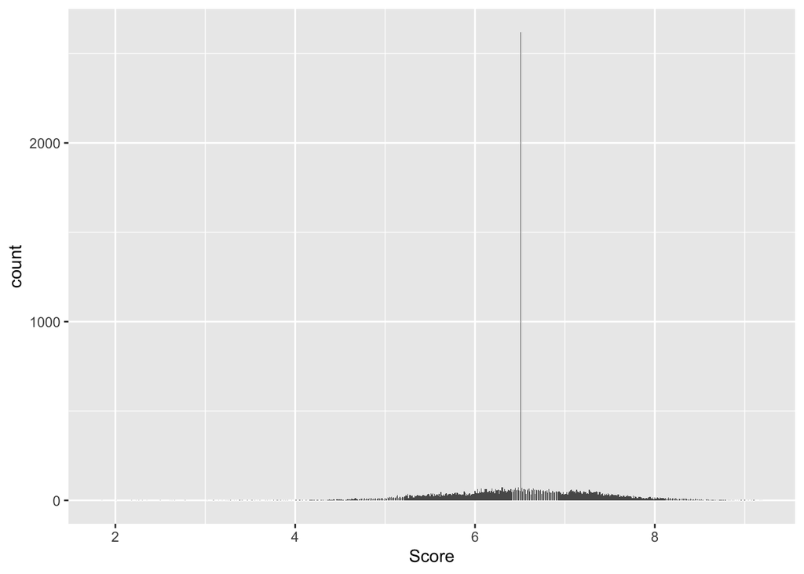

A closer look between scores of 6 and 7.

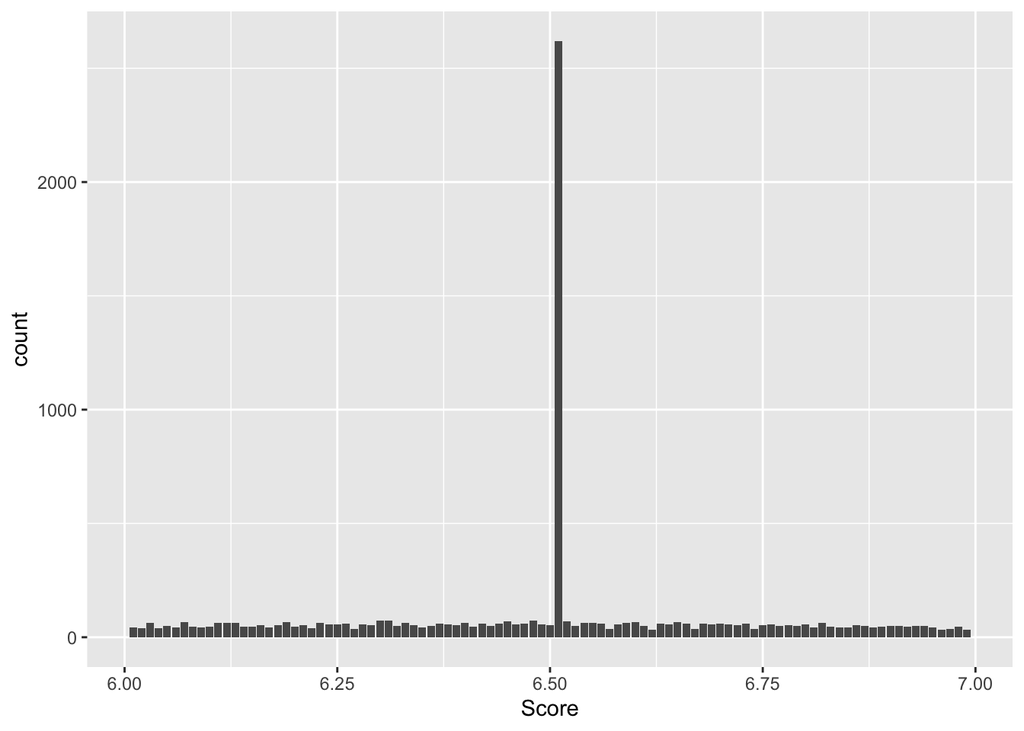

Here is a better look at the distribution outside of the score 6.51. The scores are centered around 6.2 and is left skewed.

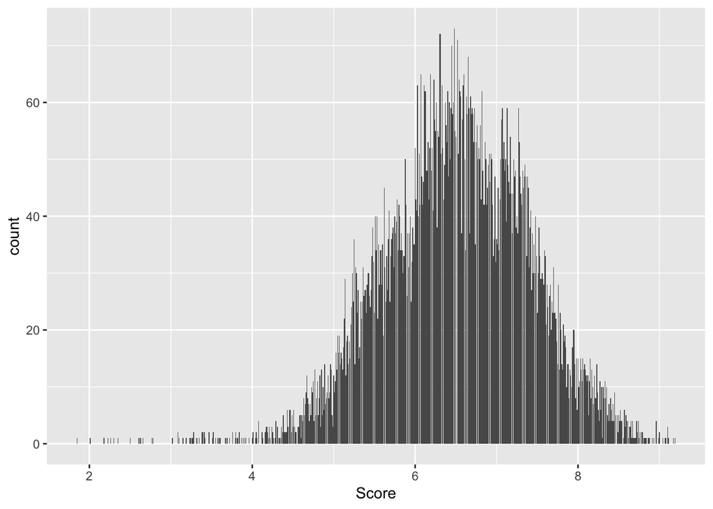